# Basic Statistics

Sergio Diez Hermano

2021-06-18

# How to organize data

Datasheets may be organized in **short** or **long** format.

- *Short* format: Columns are experimental conditions, rows have no meaning.
- *Long* format: Columns are measurements, rows are individual observations.

**GOAL** Represent all data following **long** format. That way the identity of each row is preserved (row = observation), and you can keep adding new measurements as new columns

## Short format example

### One factor

*Experimental group (ctrl, exp1, exp2)*

```r
data.frame(ctrl, exp1, exp2)
```

| ctrl | exp1 | exp2 |
| --- | --- | --- |
| 1.7478890 | 1.488001 | 9.060220 |
| 0.8673832 | 4.119860 | 7.352127 |
| 1.8621724 | 3.192403 | 5.641401 |
| 3.0909345 | 8.353119 | 5.872609 |
| 1.0771609 | 3.829878 | 9.664791 |
| 1.8859743 | 9.096685 | 8.454059 |

### Two factors

*Experimental group (ctrl, exp1, exp2)* x *Species (Fusarium circinatum, Chryphonectria parasitica)*

```r
data.frame(Fcir.ctrl = ctrl, Fcir.exp1 = exp1, Fcir.exp2 = exp2,
           Cpar.ctrl = ctrl+1.02, Cpar.exp1 = exp1+2.31, Cpar.exp2 = exp2+3.27)
```

| Fcir.ctrl | Fcir.exp1 | Fcir.exp2 | Cpar.ctrl | Cpar.exp1 | Cpar.exp2 |
| --- | --- | --- | --- | --- | --- |
| 1.7478890 | 1.488001 | 9.060220 | 2.767889 | 3.798001 | 12.330220 |
| 0.8673832 | 4.119860 | 7.352127 | 1.887383 | 6.429860 | 10.622127 |
| 1.8621724 | 3.192403 | 5.641401 | 2.882172 | 5.502403 | 8.911401 |
| 3.0909345 | 8.353119 | 5.872609 | 4.110935 | 10.663119 | 9.142609 |
| 1.0771609 | 3.829878 | 9.664791 | 2.097161 | 6.139878 | 12.934791 |
| 1.8859743 | 9.096685 | 8.454059 | 2.905974 | 11.406685 | 11.724059 |

## Long format example

### One factor

*Experimental group (ctrl, exp1, exp2)*

```r
data.frame(group = factor,
           variable = c(ctrl, exp1, exp2))
```

| group | variable |
| --- | --- |
| ctrl | 1.7478890 |
| ctrl | 0.8673832 |
| ctrl | 1.8621724 |
| ctrl | 3.0909345 |
| ctrl | 1.0771609 |
| ctrl | 1.8859743 |
| exp1 | 1.4880013 |
| exp1 | 4.1198599 |
| exp1 | 3.1924033 |
| exp1 | 8.3531195 |

[output cut: 8 more lines]

### Two factors

*Experimental group (ctrl, exp1, exp2)* x *Species (Fusarium circinatum, Chryphonectria parasitica)*

```r
data.frame(species = spec,
           group = c(factor, factor),
           variable = c(ctrl, exp1, exp2, ctrl+1.02, exp1+2.31, exp2+3.27))
```

| species | group | variable |
| --- | --- | --- |
| Fcir | ctrl | 1.7478890 |
| Fcir | ctrl | 0.8673832 |
| Fcir | ctrl | 1.8621724 |
| Fcir | ctrl | 3.0909345 |
| Fcir | ctrl | 1.0771609 |
| Fcir | ctrl | 1.8859743 |
| Fcir | exp1 | 1.4880013 |
| Fcir | exp1 | 4.1198599 |
| Fcir | exp1 | 3.1924033 |
| Fcir | exp1 | 8.3531195 |

[output cut: 26 more lines]

# Basic descriptives

Before doing any analysis it is advisable to **plot** and **summarize** the data. Common descriptors include:

- Numeric variables
  - Mean and standard deviation
  - Median and interquartilic range
  - Plot: histogram (continuous variable), correlation
- Categoric variables (factors)
  - Frequency tables
  - Plot: barplots
- Numeric x Factor
  - Mean/median per factor level
  - Plot: boxplot (**avoid** barplot)

Let’s use the following data as example:

- Numeric variables: *mRNA quantity*, *protein quantity*
- Factors: *Species (Fusarium circinatum, Chryphonectria parasitica)*, *Experimental group (ctrl, exp1, exp2)*

Here you can see a few rows of the data:

```r
# Example data
n <- 30
var1.ctrl <- rnorm(n, 2, 1)
var1.exp1 <- rnorm(n, 5, 2)
var1.exp2 <- rnorm(n, 8, 2)
var2.ctrl <- rnorm(n, 12, 1)
var2.exp1 <- rnorm(n, 10, 2)
var2.exp2 <- rnorm(n, 18, 2)
factor <- rep(c("ctrl", "exp1", "exp2"), each = n)
spec <- rep(c("Fcir", "Cpar"), each = n*3)

dataExample <- data.frame(species = spec,
                          group = c(factor, factor),
                          mrna = c(var1.ctrl, var1.exp1, var1.exp2, var1.ctrl+1.02, var1.exp1+2.31, var1.exp2+3.27),
                          protein = c(var2.ctrl, var2.exp1, var2.exp2, var2.ctrl+0.58, var2.exp1+5.84, var2.exp2+9.21))
dataExample %>% group_by(species, group) %>% sample_n(size = 3)
```

| species | group | mrna | protein |
| --- | --- | --- | --- |
| Cpar | ctrl | 4.1897453 | 15.241931 |
| Cpar | ctrl | 4.6264635 | 13.434955 |
| Cpar | ctrl | 2.8917985 | 11.670826 |
| Cpar | exp1 | 7.6496168 | 15.275734 |
| Cpar | exp1 | 9.4927341 | 13.357388 |
| Cpar | exp1 | 4.0670620 | 17.084531 |
| Cpar | exp2 | 7.5480793 | 29.811141 |
| Cpar | exp2 | 12.1813482 | 27.939857 |
| Cpar | exp2 | 7.7182948 | 25.366258 |
| Fcir | ctrl | 3.6064635 | 12.854955 |

[output cut: 8 more lines]

## Numeric variables

### Descriptive

```r
psych::describe(dataExample[, c("mrna", "protein")])
```

|  | vars | n | mean | sd | median | trimmed | mad | min | max | range | skew | kurtosis | se |
| --- | --- | --- | --- | --- | --- | --- | --- | --- | --- | --- | --- | --- | --- |
| mrna | 1 | 180 | 6.145427 | 3.601508 | 5.786468 | 5.939915 | 4.282321 | -0.9455847 | 15.29114 | 16.23672 | 0.3949198 | -0.7619605 | 0.2684405 |
| protein | 2 | 180 | 16.065438 | 6.273764 | 13.662475 | 15.390164 | 4.117603 | 5.6176803 | 31.89013 | 26.27245 | 0.9239583 | -0.1367727 | 0.4676188 |

### Plots

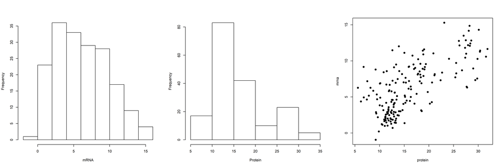

```r
par(mfrow=c(1,3))
hist(dataExample$mrna, main = "", xlab = "mRNA")
hist(dataExample$protein, main = "", xlab = "Protein")
plot(mrna ~ protein, data = dataExample, pch = 19)
```

## Factor

### Descriptive

```r
table(dataExample[, c("species", "group")])
```

```
       group
species ctrl exp1 exp2
   Cpar   30   30   30
   Fcir   30   30   30
```

### Plots

[figure not shown]

```r
par(xpd=T, cex.axis = 0.8)
barplot(table(dataExample[, c("species", "group")]), beside = T,
        col= c("blue", "orange"), ylab = "Frequency")
legend(2.5, 35,  c("Fcir", "Cpar"), fill = c("blue", "orange"), bty = "n",ncol = 2)
```

## Numeric x Factor

### Descriptive

```r
do.call(data.frame, aggregate(mrna ~ group + species, data = dataExample,
                              FUN = function(x) c(mean = mean(x), sd = sd(x),
                                                  quantile(x, .25), median = median(x), quantile(x, .75)) ) )
```

| group | species | mrna.mean | mrna.sd | mrna.25. | mrna.median | mrna.75. |
| --- | --- | --- | --- | --- | --- | --- |
| ctrl | Cpar | 3.141921 | 1.031634 | 2.468878 | 2.889408 | 4.002099 |
| exp1 | Cpar | 7.623436 | 2.244010 | 6.732882 | 7.775727 | 8.914230 |
| exp2 | Cpar | 10.970923 | 2.471394 | 9.141065 | 11.348541 | 12.682268 |
| ctrl | Fcir | 2.121921 | 1.031634 | 1.448878 | 1.869408 | 2.982099 |
| exp1 | Fcir | 5.313436 | 2.244010 | 4.422882 | 5.465727 | 6.604230 |
| exp2 | Fcir | 7.700923 | 2.471394 | 5.871065 | 8.078541 | 9.412268 |

```r
do.call(data.frame, aggregate(protein ~ group + species, data = dataExample,
                              FUN = function(x) c(mean = mean(x), sd = sd(x),
                                                  quantile(x, .25), median = median(x), quantile(x, .75)) ) )
```

| group | species | protein.mean | protein.sd | protein.25. | protein.median | protein.75. |
| --- | --- | --- | --- | --- | --- | --- |
| ctrl | Cpar | 12.60542 | 1.104517 | 11.707816 | 12.622555 | 13.24489 |
| exp1 | Cpar | 15.50932 | 2.027056 | 14.141505 | 15.420384 | 16.98169 |
| exp2 | Cpar | 27.89657 | 2.057824 | 26.800060 | 27.850521 | 29.30582 |
| ctrl | Fcir | 12.02542 | 1.104517 | 11.127816 | 12.042555 | 12.66489 |
| exp1 | Fcir | 9.66932 | 2.027056 | 8.301505 | 9.580384 | 11.14169 |
| exp2 | Fcir | 18.68657 | 2.057824 | 17.590060 | 18.640521 | 20.09582 |

### Plots

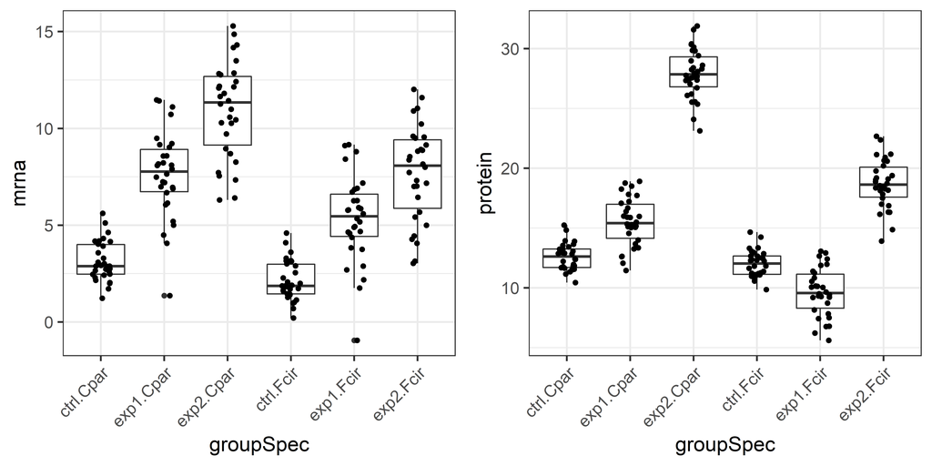

```r
dataExample$groupSpec <- interaction(dataExample$group, dataExample$species)

mrnaBox <- ggplot(dataExample, aes(groupSpec, mrna)) +
  geom_boxplot() +
  geom_jitter(width=0.15) +
  theme_bw(16) +
  theme(axis.text.x = element_text(angle = 45, hjust=1))

proteinBox <- ggplot(dataExample, aes(groupSpec, protein)) +
  geom_boxplot() +
  geom_jitter(width=0.15) +
  theme_bw(16) +
  theme(axis.text.x = element_text(angle = 45, hjust=1))

ggpubr::ggarrange(mrnaBox, proteinBox,
          ncol = 2, nrow = 1)
```